# Tuna supply chain, slice 1

Ernesto Carrella

4/18/2021

## Rationale

Wanted to quickly build a supply-chain model that could integrate the data we have. The objective here is to test what kind of conflicts are present in the data and what can already be established from a quick model.  
This is still much simpler than what we want, but it’s a good place to start.

Instantiated with 2011 numbers because they were easy to find in reports (particularly GLOBEFISH, Jenny Sun’s FAO reports and the blue book) but most of FAO data is available for 2018, so that shouldn’t be too much of a problem.

## Model

This is a cost-minimization model.  
This means that we take the fish landed and the loins/canned tuna demanded as given. The objective of the model is to move, clean, process and sell fish product from ports to markets.

The best way to imagine it is as the decision process of a completely integrated EPO supply chain. You get landings “for free” (as in, you have already paid for them) but need to process them in the right place and transport them to the local or European market; however you can also buy loins or tuna cans directly from Thailand as a substitute.

[interactive chart not shown]

Port landings, processors and canneries are modeled at a country level within the EPO. WCPO imports (of cooked loins and/or finished products) are modeled as fixed price imports (i.e. you can buy as many as you want for a fixed price). Final demand (of loins and finished products) is fixed and not interchangeable.

The model looks for the cheapest path for landed/imported product to fulfill required demands.  
The output of the model are “shadow” prices: how much would you be willing to pay for an additional ton of fish landed in each country (or to fulfill one more unit of demand).

There is little heterogeneity: all countries have equal costs and productivity (recovery rate) but landings are more concentrated in Ecuador and Mexico. Transportation costs differ between each country pair but are equal for all good types; The data comes from UNCTAD and unfortunately exists only for trades that did occur (if Ecuador sent no product to Costa Rica, UNCTAD can’t tell us what the $/t cost would have been).  
Transportation costs from UNCTAD also seem to not have much to do with geography (it’s about 10 times cheaper to move product from Ecuador to Spain than from Ecuador to Mexico) but that seems to be an important feature of that dataset rather than a bug.

The only tariffs currently in the model are those from Thailand to Europe (“Spain”) and they are 22% on loins and 24% on canned.

## Results

The supply chain structure that emerges from the data we have is as follows:

- Most cleaning occurs where fish is landed; transportation of raw tuna occurs only for countries with no processors
- Thai loins are so cheap that:
  - EPO does not export any loins to Europe, Thai loins to fulfill the entire loin demand from spain
  - Mexican canneries import large quantities of Thai loins to produce canned tuna (for both local and foreign markets)
- Because of tariffs, all European canned demand is fulfilled by Ecuador and Mexico.
- Smaller local canneries produce exclusively for the local market

[interactive chart not shown]

The two main weird results are that (i) WCPO in this model only appears in the loining market and not the canned market, (ii) Mexico is a major exporter to Europe.  
My guess is that the 2011 prices I have for Thailand imports are not consistent. Both come from GLOBEFISH by simply dividing value traded for tonnes imported.

Pre-tariff prices amount to 3000$/ton for loins and 4000$/ton for canned. With this differential you are better off buying WCPO loins at 3000$, moving it into Mexico for 135$, pay 46$ for canning it and then pay 72$ for shipping it to Spain.  
So either the WCPO price differential is not that large or we are missing some tariffs or additional costs in the manufacturing itself.

Mexico exporting to Europe seems to me to be a problem of not modeling tariffs correctly (in this model Mexico exports are untaxed), which underlines the importance of getting those numbers right.

The main good result of this simulation that the ex-vessel prices from the model look about right. In most countries landings are worth around 1500$ per tonne which matches the prices in 2011 in Santiago’s cash-flow simulations. The prices are quite similar across ports except when fish is landed far away from canneries (since you need to pay to transport it there)

| Port | Shadow Price |
| --- | --- |
| Colombia | 1503.64 |
| Costa Rica | 1503.64 |
| Ecuador | 1511.36 |
| El Salvador | 1503.64 |
| Guatemala | 1504.96 |
| Kiribati | 1410.55 |
| Mexico | 1503.64 |
| Panama | 1477.00 |
| Peru | 1482.84 |
| Solomon Islands | 1408.64 |

It is interesting to note that prices are very inelastic to landings. That is, even large variation in landings will not have much direct impact on prices. This may change with inventories, demand functions, etc; however it is interesting because this is our main focus for POSEIDON.

Why is the demand so inelastic?  
Because the markets are integrated and so the benefit of landing more fish is the money you saved by not having to import loins from the WCPO. Since the WCPO prices are unaffected by policy in the EPO (at least here, by construction) then demand curves for ex-vessel landings will be very flat (you save the same amount for whatever you land). For the same reason then, ex-vessel prices in the EPO will be very sensitive to changes in prices from the WCPO, since the landing prices are fundamentally opportunity costs. Notice that here I am plotting Ecuador prices which in this model do not even interact directly with the WCPO.

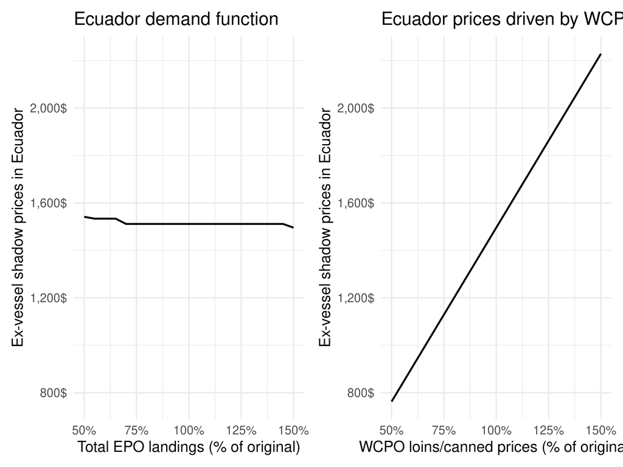

## Next steps

We obviously still missing many mechanisms, particularly:

- demand functions
- inventories
- monthly dynamics
- tariffs
- separate species

This however was primarily an exercise looking at what problems emerge from trying to put the data together.

Overall the prices that come out of the model make sense, which implies that most of the data is in agreement and consistent with our theoretical understanding of the market.

The main unrealistic output of the model is the sharp split between an European loin market dominated by Thai processors but a canned market dominated by EPO canneries (especially the much higher contribution from Mexico). As argued above the problem lies somewhere between the lack of tariffs and the correct WCPO prices. The latter may be easier to obtain for 2018 however (we can get them directly from the thai cannery association) so hopefully this problem will fix itself.

There are a ton of ancilliary questions that would be better dealt with an email to the group, in particular: * The market for live fish, particularly Mexican import * The local EPO market for canned fish * “recovery rates” between loins and canned product